# HW1 Problem4

**Consider a distribution with pdf** $$p(x,y) \propto 1(|x-y|<c)1((x,y) \in (0,1)^2)$$

*python script: hw1prob4.py*

Before starting, let's illustrate this density. This distribution is uniform over the region that the below picture shows:

[figure not shown]

From this picture, we can easily find that

$$x|y \sim unif[max(0, y-c), min(1, y+c)]$$$$y|x \sim unif[max(0, x-c), min(1, x+c)]$$

## 4-(a)

**Derive a Gibbs sampler to sample from this distribution.**

We already found the full-conditional distributions for $x$ and $y$. Here is algorithm:

1. Set an initial point $(x^{0},y^{0})$,
2. For $b=1,2,...,B$,
   - draw $x^b \sim unif[max(0, y^{b-1}-c), min(1, y^{b-1}+c)]$
   - draw $y^b \sim unif[max(0, x^{b}-c), min(1, x^{b}+c)]$
   - keep $(x^b, y^b)$
3. Cut burn-in period and do thinning if they are needed.

An implemention is easy, cause we need to sample from two uniform distribution only. The below class *MCMC_Gibbs_hw1p5* shows the algorithm straightforwardly.

```python
from random import seed, uniform

from bayesian_tools.MCMC_Core import MCMC_Gibbs, MCMC_Diag

class MCMC_Gibbs_hw1p5(MCMC_Gibbs):
    def __init__(self, initial, c):
        super().__init__(initial)
        self.c = c

    def full_conditional_sampler_x(self, last_param):
        new_sample = [x for x in last_param]
        new_x = uniform(max(0, new_sample[1]-self.c), min(1, new_sample[1]+self.c))
        new_sample[0] = new_x
        return new_sample

    def full_conditional_sampler_y(self, last_param):
        new_sample = [x for x in last_param]
        new_y = uniform(max(0, new_sample[0]-self.c), min(1, new_sample[0]+self.c))
        new_sample[1] = new_y
        return new_sample

    def sampler(self):
        last = self.MC_sample[-1]
        new = [x for x in last] #[nu, theta]
        #update new
        new = self.full_conditional_sampler_x(new)
        new = self.full_conditional_sampler_y(new)
        self.MC_sample.append(new)
```

Also see *MCMC_Core.py*: https://github.com/letsjdosth/BayesModeling/blob/main/bayesian_tools/MCMC_Core.py

## 4-(b)(c)(d)

**Implement the Gibbs sampler for 1000 iterations for each of the following: $c=0.3, c=0.05$ and $c=0.01$.** **For each value of the $c$, make a traceplot of x and a scatter plot of (x,y)**. **What do you see as c gets smaller?**

I will construct three instances for each c values and show traceplots and scatterplots respectively.

For all caces, I set (0.5, 0.5) as an initial value, cause the point is always within the support of the given density as long as $c>0$.

To begin with, let's set $c=0.3$.

```
estimated running time:  0.0 min  0.0 sec
iteration 500 / 1000
iteration 1000 / 1000  done! (elapsed time for execution:  0.0 min  0.057381629943847656 sec)
```

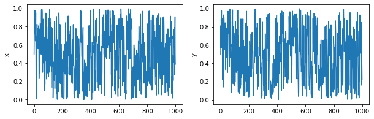

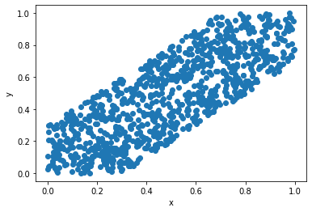

```python
seed(20220402)

initial = [0.5, 0.5]
gibbs_inst1 = MCMC_Gibbs_hw1p5(initial, c=0.3)
gibbs_inst1.generate_samples(1000)
gibbs_inst1_diag = MCMC_Diag()
gibbs_inst1_diag.set_mc_sample_from_MCMC_instance(gibbs_inst1)
gibbs_inst1_diag.set_variable_names(["x","y"])
gibbs_inst1_diag.show_traceplot((1,2))
# gibbs_inst1_diag.show_acf(30, (1,2))
# gibbs_inst1_diag.show_hist((1,2))
gibbs_inst1_diag.show_scatterplot(0,1)
```

The traceplots seem good. Scatterplot is coherent with the (analytic) illustration in the head part of this file.

Next, let's set $c=0.05$.

```
estimated running time:  0.0 min  0.004787445068359375 sec
iteration 500 / 1000
iteration 1000 / 1000  done! (elapsed time for execution:  0.0 min  0.016540050506591797 sec)
```

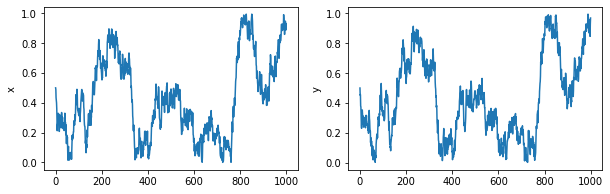

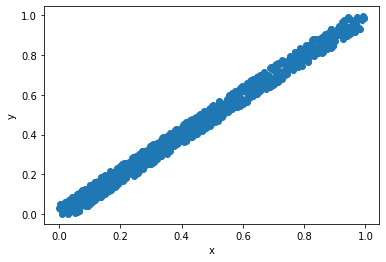

```python
gibbs_inst2 = MCMC_Gibbs_hw1p5(initial, c=0.05)
gibbs_inst2.generate_samples(1000)
gibbs_inst2_diag = MCMC_Diag()
gibbs_inst2_diag.set_mc_sample_from_MCMC_instance(gibbs_inst2)
gibbs_inst2_diag.set_variable_names(["x","y"])
gibbs_inst2_diag.show_traceplot((1,2))
# gibbs_inst2_diag.show_acf(30, (1,2))
# gibbs_inst2_diag.show_hist((1,2))
gibbs_inst2_diag.show_scatterplot(0,1)
```

These traceplots seem bad. Even if the scatterplot is not too bad, it is suspicious to belive that our Gibbs sampler generated posterior samples properly.

But unfortunately, it is an intrinsic(?) limit of the Gibbs sampler. This problem is inevitable if we don't apply an axis transformation or don't give up using the Gibbs sampler, cause the Gibbs sampler can move through each axis direction only for each sub-step of the step 2 in the algorithm. As a result, cause the support that the sampler can move to each axis-direction becomes so narrow as $c$ gets smaller in this case, the Gibbs sampler faces a situration that gets harder to explore entire parameter space within the small number of iterations. This is what the traceplots are showing us.

```
estimated running time:  0.0 min  0.0 sec
iteration 500 / 1000
iteration 1000 / 1000  done! (elapsed time for execution:  0.0 min  0.00757598876953125 sec)
```

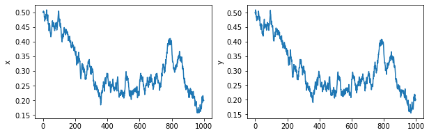

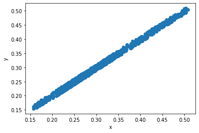

```python
gibbs_inst3 = MCMC_Gibbs_hw1p5(initial, c=0.01)
gibbs_inst3.generate_samples(1000)
gibbs_inst3_diag = MCMC_Diag()
gibbs_inst3_diag.set_mc_sample_from_MCMC_instance(gibbs_inst3)
gibbs_inst3_diag.set_variable_names(["x","y"])
gibbs_inst3_diag.show_traceplot((1,2))
# gibbs_inst3_diag.show_acf(30, (1,2))
# gibbs_inst3_diag.show_hist((1,2))
gibbs_inst3_diag.show_scatterplot(0,1)
```

Since we set $c$ as more smaller value, the problem I mentioned above got more serious. I think we should avoid to use the Gibbs sampler when $c$ is close to $0$.